# Peer 1

# Reproducible Research: Peer Assessment 1

1. Load the data (i.e. read.csv()) and process/transform the data into a format suitable for your analysis

```r
library(ggplot2)
 library(plyr)
 activity <- read.csv("activity.csv",colClasses=c("numeric","Date","numeric"))
```

# What is mean total number of steps taken per day?

1. Make a histogram of the total number of steps taken each day

Calculate and report the mean and median total number of steps taken per day

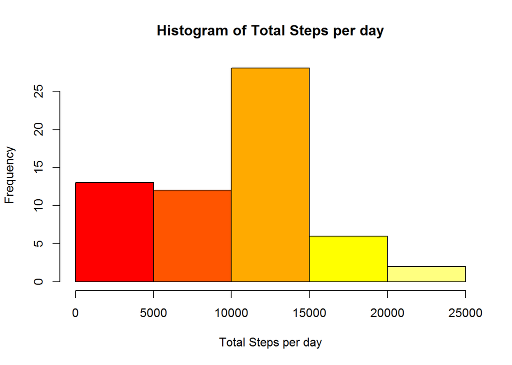

```r
sum_by_date <- tapply(activity$steps,activity$date,sum,na.rm=TRUE)
 sum_steps_per_day <- tapply(activity$steps,activity$date,sum,na.rm=TRUE)


hist(sum_steps_per_day,col=heat.colors(5),xlab="Total Steps per day",main="Histogram of Total Steps per day")
```

2. Calculate and report the mean and median total number of steps taken per day

```r
mean(sum_steps_per_day)
```

```
## [1] 9354.23
```

```r
median(sum_steps_per_day)
```

```
## [1] 10395
```

# What is the average daily activity pattern?

1. We will make a time series plot (i.e. type = “l”) of the 5-minute interval (x-axis) and the average number of steps taken, averaged across all days (y-axis)

```r
mean_by_interval <- tapply(activity$steps,activity$interval,mean,na.rm=TRUE)
```

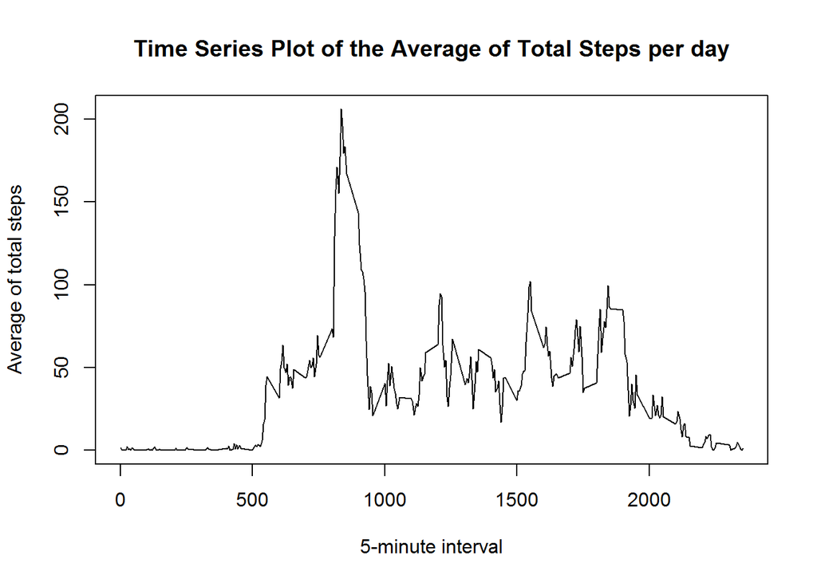

```r
plot(row.names(mean_by_interval),mean_by_interval,type="l",xlab="5-minute interval",ylab="Average of total steps",main="Time Series Plot of the Average of Total Steps per day")
```

2.Which 5-minute interval, on average across all the days in the dataset, contains the maximum number of steps?

```r
x <- max(mean_by_interval)
match(x,mean_by_interval)
```

```
## [1] 104
```

```r
mean_by_interval[104]
```

```
##      835
## 206.1698
```

# Imputing missing values

1.Calculate and report the total number of missing values in the dataset (i.e. the total number of rows with NAs) 2.Devise a strategy for filling in all of the missing values in the dataset. The strategy does not need to be sophisticated. For example, you could use the mean/median for that day, or the mean for that 5-minute interval, etc. 3.Create a new dataset that is equal to the original dataset but with the missing data filled in.

```r
sum(is.na(activity))
```

```
## [1] 2304
```

```r
activity_na <- activity[is.na(activity),]
activity_no_na <- activity[complete.cases(activity),]
activity_na$steps <- as.numeric(mean_by_interval)
new_activity <- rbind(activity_na,activity_no_na)
new_activity <-  new_activity[order(new_activity[,2],new_activity[,3]),]
```

4.Make a histogram of the total number of steps taken each day and Calculate and report the mean and median total number of steps taken per day.

```r
new_daily_sum <- tapply(new_activity$steps,new_activity$date,sum)
```

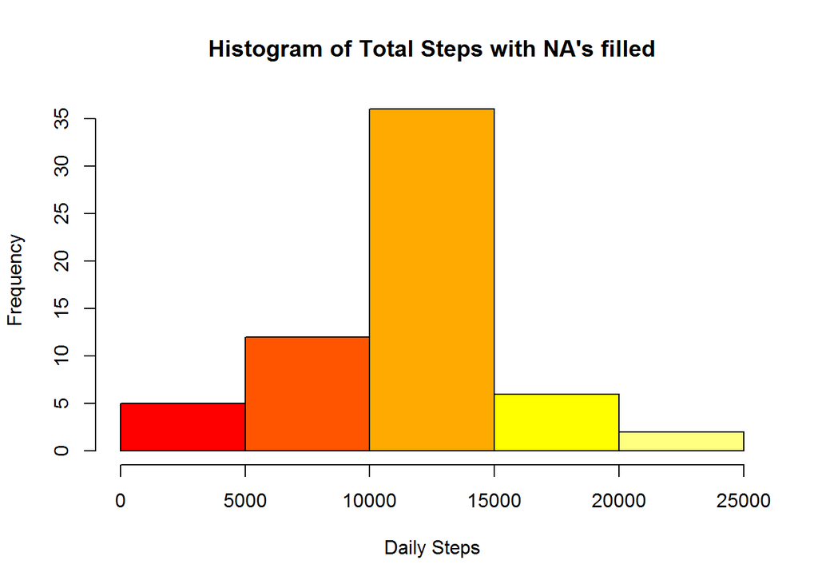

```r
hist(new_daily_sum,col=heat.colors(5),xlab="Daily Steps",main="Histogram of Total Steps with NA's filled")
```

```r
mean(new_daily_sum)
```

```
## [1] 10766.19
```

```r
median(new_daily_sum)
```

```
## [1] 10766.19
```

# Are there differences in activity patterns between weekdays and weekends?

1.Create a new factor variable in the dataset with two levels – “weekday” and “weekend” indicating whether a given date is a weekday or weekend day.

```r
days <- weekdays(new_activity[,2])
new_activity <- cbind(new_activity,days)

library(plyr)

new_activity$days <- revalue(new_activity$days,c("Δευτέρα"="weekday","Τρίτη"="weekday","Τετάρτη"="weekday","Πέμπτη"="weekday","Παρασκευή"="weekday"))

new_activity$days <- revalue(new_activity$days,c("Σάββατο"="weekend","Κυριακή"="weekend"))


new_mean_interval <- tapply(new_activity$steps,list(new_activity$interval,new_activity$days),mean)

library(reshape2)
new_mean_interval <- melt(new_mean_interval)
colnames(new_mean_interval) <- c("interval","day","steps")
library(lattice)
```

2.Make a panel plot containing a time series plot (i.e. type = “l”) of the 5-minute interval (x-axis) and the average number of steps taken, averaged across all weekday days or weekend days (y-axis)

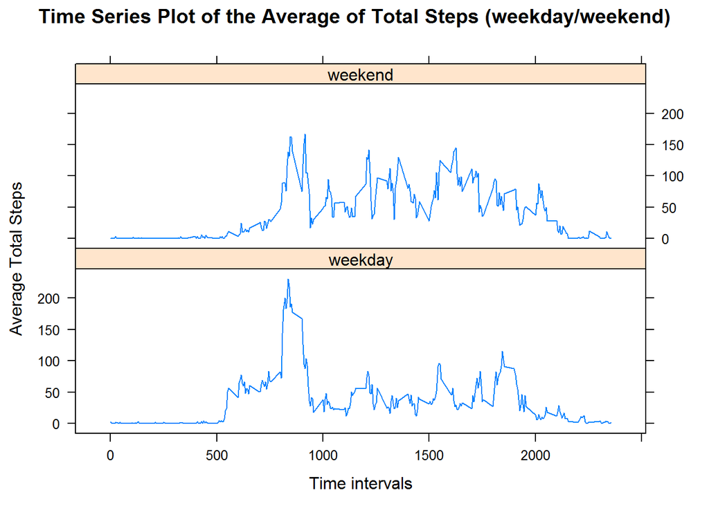

```r
xyplot(new_mean_interval$steps ~ new_mean_interval$interval | new_mean_interval$day, layout=c(1,2),type="l",main="Time Series Plot of the Average of Total Steps (weekday/weekend)",xlab="Time intervals",ylab="Average Total Steps")
```